# HW 2: Supervised Learning Models

```python
import pandas as pd
import numpy as np
import seaborn as sns
%matplotlib inline
```

## Part 1: Regression on California Test Scores

### Qn1.1) Visualize the univariate distribution of the target feature and each of the three continuous explanatory variables that you think are likely to have a relationship with the target feature.

```python
#Data Cleaning
df = pd.read_csv("https://vincentarelbundock.github.io/Rdatasets/csv/Ecdat/Caschool.csv")
df = df.drop(columns=['readscr', 'mathscr'])
df = df.iloc[:, 5:]
df.head()
```

|  | enrltot | teachers | calwpct | mealpct | computer | testscr | compstu | expnstu | str | avginc | elpct |
| --- | --- | --- | --- | --- | --- | --- | --- | --- | --- | --- | --- |
| 0 | 195 | 10.900000 | 0.510200 | 2.040800 | 67 | 690.799988 | 0.343590 | 6384.911133 | 17.889910 | 22.690001 | 0.000000 |
| 1 | 240 | 11.150000 | 15.416700 | 47.916698 | 101 | 661.200012 | 0.420833 | 5099.380859 | 21.524664 | 9.824000 | 4.583333 |
| 2 | 1550 | 82.900002 | 55.032299 | 76.322601 | 169 | 643.599976 | 0.109032 | 5501.954590 | 18.697226 | 8.978000 | 30.000002 |
| 3 | 243 | 14.000000 | 36.475399 | 77.049202 | 85 | 647.700012 | 0.349794 | 7101.831055 | 17.357143 | 8.978000 | 0.000000 |
| 4 | 1335 | 71.500000 | 33.108601 | 78.427002 | 171 | 640.849976 | 0.128090 | 5235.987793 | 18.671329 | 9.080333 | 13.857677 |

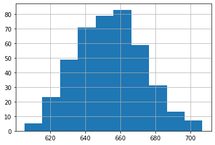

```python
df['testscr'].hist()
```

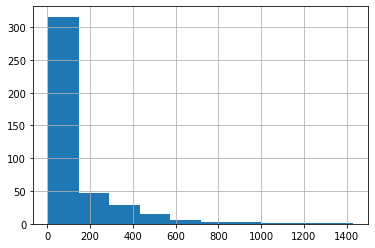

```python
df['teachers'].hist()
```

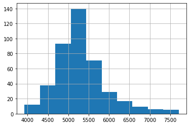

```python
df['expnstu'].hist()
```

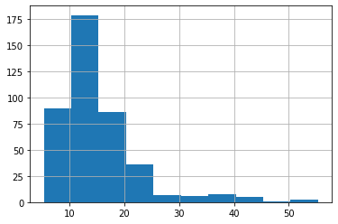

```python
df['avginc'].hist()
```

### Qn1.2) Visualize the dependency of the target on each feature from 1.1.

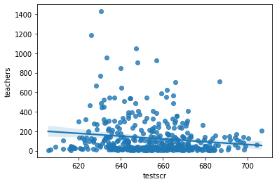

```python
x = sns.regplot(x="testscr", y="teachers", data=df)
```

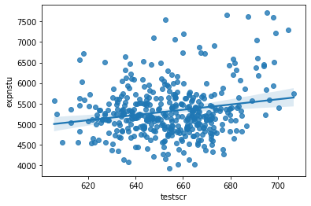

```python
x = sns.regplot(x="testscr", y="expnstu", data=df)
```

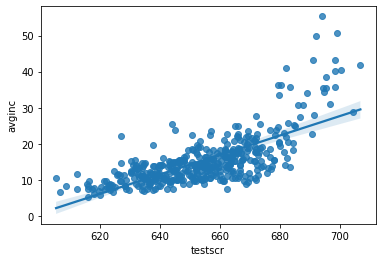

```python
x = sns.regplot(x="testscr", y="avginc", data=df)
```

### Qn1.3) Split data in training and test set. Build models that evaluate the relationship between all available X variables in the California test dataset and the target variable. Evaluate KNN for regression, Linear Regression (OLS), Ridge, and Lasso using cross-validation with the default parameters. Does scaling the data with the StandardScaler help?

```python
from sklearn.model_selection import train_test_split
```

#### Split data in training and test set.

```python
Y = df['testscr']
X = df.loc[:, df.columns != 'testscr']
X_train, X_test, y_train, y_test = train_test_split(X, Y, random_state=42)
print(X.shape)
X_train.shape
```

```
(420, 10)
```

```
(315, 10)
```

#### Build models that evaluate the relationship between all available X variables in the California test dataset and the target variable.

```python
from sklearn.model_selection import cross_val_score
from sklearn.model_selection import KFold

kfold = KFold(n_splits=10)
```

#### Evaluate KNN for regression using cross-validation (Unscaled)

```python
from sklearn.neighbors import KNeighborsRegressor

knn = KNeighborsRegressor(n_neighbors=10)
knn.fit(X_train, y_train)

print("Training Set Score: {:.2f}".format(knn.score(X_train, y_train)))
print("Test Set Score: {:.2f}".format(knn.score(X_test, y_test)))
regression_unscaled = np.mean(cross_val_score(knn, X_train, y_train, cv=kfold))
print("Unscaled KFold Cross Validation:{:.2f}".format(regression_unscaled))
```

```
Training Set Score: 0.18
Test Set Score: 0.03
Unscaled KFold Cross Validation:0.01
```

#### Evaluate Linear Regression (OLS) using cross-validation (Unscaled)

```python
from sklearn.linear_model import LinearRegression

lr = LinearRegression()
lr.fit(X_train, y_train)

print("Training Set Score: {:.2f}".format(lr.score(X_train, y_train)))
print("Test Set Score: {:.2f}".format(lr.score(X_test, y_test)))
ols_unscaled = np.mean(cross_val_score(lr, X_train, y_train, cv=kfold, scoring="r2"))
print("Unscaled KFold Cross Validation:{:.2f}".format(ols_unscaled))
```

```
Training Set Score: 0.81
Test Set Score: 0.81
Unscaled KFold Cross Validation:0.78
```

#### Evaluate Ridge using cross-validation (Unscaled)

```python
from sklearn.linear_model import Ridge

ridge = Ridge().fit(X_train, y_train)

print("Training Set Score: {:.2f}".format(ridge.score(X_train, y_train)))
print("Test Set Score: {:.2f}".format(ridge.score(X_test, y_test)))
ridge_unscaled = np.mean(cross_val_score(ridge, X_train, y_train, cv=kfold))
print("Unscaled KFold Cross Validation: {:.2f}".format(ridge_unscaled))
```

```
Training Set Score: 0.81
Test Set Score: 0.81
Unscaled KFold Cross Validation: 0.78
```

#### Evaluate Lasso using cross-validation (Unscaled)

```python
from sklearn.linear_model import Lasso
lasso = Lasso(alpha=0.01, max_iter=10000).fit(X_train, y_train)

print("Training Set Score: {:.2f}".format(lasso.score(X_train, y_train)))
print("Test Set Score: {:.2f}".format(lasso.score(X_test, y_test)))
lasso_unscaled = np.mean(cross_val_score(lasso, X_train, y_train, cv=kfold))
print("Unscaled KFold Cross Validation: {:.2f}".format(lasso_unscaled))
```

```
Training Set Score: 0.81
Test Set Score: 0.81
Unscaled KFold Cross Validation: 0.78
```

```python
from sklearn import preprocessing
from sklearn.preprocessing import StandardScaler

scaler = preprocessing.StandardScaler()
scaler.fit(X_train)
X_train_scaled = scaler.transform(X_train)
X_test_scaled = scaler.transform(X_test)
```

#### Evaluate KNN for regression using cross-validation (Scaled)

```python
knn = KNeighborsRegressor(n_neighbors=10)
knn.fit(X_train_scaled, y_train)

print("Training Set Score: {:.2f}".format(knn.score(X_train_scaled, y_train)))
print("Test Set Score: {:.2f}".format(knn.score(X_test_scaled, y_test)))
regression_scaled = np.mean(cross_val_score(knn, X_train_scaled, y_train, cv=kfold))
print("Scaled KFold Cross Validation:{:.2f}".format(regression_scaled))
```

```
Training Set Score: 0.78
Test Set Score: 0.78
Scaled KFold Cross Validation:0.72
```

```python
print("Unscaled KFold Cross Validation:{:.2f}".format(regression_unscaled))
print("Scaled KFold Cross Validation:{:.2f}".format(regression_scaled))
```

```
Unscaled KFold Cross Validation:0.01
Scaled KFold Cross Validation:0.72
```

We can see from the result that scaling the data with the StandardScaler has largely improved the average accuracy of the knn regression model.

#### Evaluate Linear Regression (OLS) using cross-validation (Scaled)

```python
lr = LinearRegression()
lr.fit(X_train_scaled, y_train)

print("Training Set Score: {:.2f}".format(lr.score(X_train_scaled, y_train)))
print("Test Set Score: {:.2f}".format(lr.score(X_test_scaled, y_test)))
ols_scaled = np.mean(cross_val_score(lr, X_train_scaled, y_train, cv=kfold, scoring="r2"))
print("Scaled KFold Cross Validation:{:.2f}".format(ols_scaled))
```

```
Training Set Score: 0.81
Test Set Score: 0.81
Scaled KFold Cross Validation:0.78
```

```python
print("Unscaled KFold Cross Validation:{:.2f}".format(ols_unscaled))
print("Scaled KFold Cross Validation:{:.2f}".format(ols_scaled))
```

```
Unscaled KFold Cross Validation:0.78
Scaled KFold Cross Validation:0.78
```

We can see from the result that scaling the data with the StandardScaler does not improve the average accuracy of the OLS model.

#### Evaluate Ridge using cross-validation (Scaled)

```python
ridge = Ridge().fit(X_train_scaled, y_train)

print("Training Set Score: {:.2f}".format(ridge.score(X_train_scaled, y_train)))
print("Test Set Score: {:.2f}".format(ridge.score(X_test_scaled, y_test)))
ridge_scaled = np.mean(cross_val_score(ridge, X_train_scaled, y_train, cv=kfold))
print("Scaled KFold Cross Validation: {:.2f}".format(ridge_scaled))
```

```
Training Set Score: 0.81
Test Set Score: 0.81
Scaled KFold Cross Validation: 0.78
```

```python
print("Unscaled KFold Cross Validation:{:.2f}".format(ridge_unscaled))
print("Scaled KFold Cross Validation: {:.2f}".format(ridge_scaled))
```

```
Unscaled KFold Cross Validation:0.78
Scaled KFold Cross Validation: 0.78
```

We can see from the result that scaling the data with the StandardScaler does not improve the average accuracy of the Ridge model.

#### Evaluate Lasso using cross-validation (Scaled)

```python
lasso = Lasso(alpha=0.01, max_iter=10000).fit(X_train_scaled, y_train)

print("Training Set Score: {:.2f}".format(lasso.score(X_train_scaled, y_train)))
print("Test Set Score: {:.2f}".format(lasso.score(X_test_scaled, y_test)))
lasso_scaled = np.mean(cross_val_score(lasso, X_train_scaled, y_train, cv=kfold))
print("Scaled KFold Cross Validation: {:.2f}".format(lasso_scaled))
```

```
Training Set Score: 0.81
Test Set Score: 0.81
Scaled KFold Cross Validation: 0.78
```

```python
print("Unscaled KFold Cross Validation:{:.2f}".format(lasso_unscaled))
print("Scaled KFold Cross Validation: {:.2f}".format(lasso_scaled))
```

```
Unscaled KFold Cross Validation:0.78
Scaled KFold Cross Validation: 0.78
```

We can see from the result that scaling the data with the StandardScaler does not improve the average accuracy of the Lasso model.

### Qn1.4) Tune the parameters of the models where possible using GridSearchCV. Do the results improve?

```python
from sklearn.pipeline import make_pipeline
from sklearn.model_selection import GridSearchCV
```

#### GridsearchCV with KNN Regression

```python
knn_pipe = make_pipeline(StandardScaler(), KNeighborsRegressor())
param_grid = {'kneighborsregressor__n_neighbors': range(1, 18, 2)}
grid = GridSearchCV(knn_pipe, param_grid, cv=kfold)
grid.fit(X_train_scaled, y_train)
print("Training Set Score: {:.2f}".format(grid.score(X_train_scaled, y_train)))
print("Test Set Score: {:.2f}".format(grid.score(X_test_scaled, y_test)))
print("Best Parameter: {}".format(grid.best_params_))
```

```
Training Set Score: 0.77
Test Set Score: 0.76
Best Parameter: {'kneighborsregressor__n_neighbors': 15}
```

```python
print("KNN before GridsearchCV: {:.5f}".format(regression_scaled))
knn = KNeighborsRegressor(n_neighbors=15).fit(X_train_scaled, y_train)
print("KNN after GridsearchCV: {:.5f}".format(knn.score(X_test_scaled, y_test)))
```

```
KNN before GridsearchCV: 0.71899
KNN after GridsearchCV: 0.75838
```

The result has improved using GridSearchCV.

#### GridsearchCV with Linear Regression (OLS)

OLS do not have parameters to be tuned.

#### Gridsearch with Ridge Regression

```python
ridge_pipe = make_pipeline(StandardScaler(), Ridge())
param_grid = {'ridge__alpha': np.linspace(0.1, 100.1, 1)}
grid = GridSearchCV(ridge_pipe, param_grid, cv=kfold)
grid.fit(X_train_scaled, y_train)
print("Training Set Score: {:.2f}".format(grid.score(X_train_scaled, y_train)))
print("Test Set Score: {:.2f}".format(grid.score(X_test_scaled, y_test)))
print("Best Parameter: {}".format(grid.best_params_))
```

```
Training Set Score: 0.81
Test Set Score: 0.81
Best Parameter: {'ridge__alpha': 0.1}
```

```python
print("Ridge before GridsearchCV: {:.5f}".format(ridge_scaled))
ridge = Ridge(alpha=0.1,max_iter=100000).fit(X_train_scaled, y_train)
print("Ridge after GridsearchCV: {:.5f}".format(ridge.score(X_test_scaled, y_test)))
```

```
Ridge before GridsearchCV: 0.78170
Ridge after GridsearchCV: 0.80705
```

The result has improved using GridSearchCV.

#### Gridsearch with LASSO Regression

```python
lasso_pipe = make_pipeline(StandardScaler(), Lasso())
param_grid = {'lasso__alpha': np.linspace(0.1, 100.0, 1)}
grid = GridSearchCV(lasso_pipe, param_grid, cv=kfold)
grid.fit(X_train_scaled, y_train)
print("Training Set Score: {:.2f}".format(grid.score(X_train_scaled, y_train)))
print("Test Set Score: {:.2f}".format(grid.score(X_test_scaled, y_test)))
print("Best Parameter: {}".format(grid.best_params_))
```

```
Training Set Score: 0.81
Test Set Score: 0.81
Best Parameter: {'lasso__alpha': 0.1}
```

```python
print("Lasso before GridsearchCV: {:.5f}".format(lasso_scaled))
lasso = Lasso(alpha=0.1, max_iter=100000).fit(X_train_scaled, y_train)
print("Lasso after GridsearchCV: {:.5f}".format(lasso.score(X_test_scaled, y_test)))
```

```
Lasso before GridsearchCV: 0.78173
Lasso after GridsearchCV: 0.80548
```

The result has improved using GridSearchCV.

### Qn1.5) Compare the coefficients of your two best linear models (not knn), do they agree on which features are important?

```python
pd.DataFrame(data={'Lasso':lasso.coef_, 'Ridge': ridge.coef_}, index=X.columns)
```

|  | Lasso | Ridge |
| --- | --- | --- |
| enrltot | -0.000000 | 0.777656 |
| teachers | -0.000000 | -1.706045 |
| calwpct | -1.015310 | -1.181975 |
| mealpct | -9.931920 | -9.763967 |
| computer | 0.000000 | 1.022309 |
| compstu | 0.019521 | -0.093965 |
| expnstu | 1.074776 | 1.155323 |
| str | -0.580477 | -0.669615 |
| avginc | 3.697999 | 3.720510 |
| elpct | -3.349810 | -3.483024 |

My two best linear models are Ridge and Lasso. As seen from the comparison table above, we can see that they do agreee on which features are important. For example, both models indicate that 'mealpct' and 'elpct' are negatively correlated with 'testscr'. 'expnstu' and 'anginc' are positively correlated with 'testscr'.

### Qn1.6) Discuss which final model you would choose to predict new data.

I will choose Ridge model as it has the highest average accuracy of 0.80705.

## Part 2: Classification on red and white wine characteristics

```python
from sklearn.model_selection import RepeatedKFold
from sklearn.model_selection import StratifiedKFold

skfold = StratifiedKFold(n_splits=10, shuffle=True)
rkf = RepeatedKFold(n_splits=10, n_repeats=4, random_state = 42)
```

```python
#Data Cleaning
red = pd.read_csv("https://archive.ics.uci.edu/ml/machine-learning-databases/wine-quality/winequality-red.csv", sep=';')
white = pd.read_csv("https://archive.ics.uci.edu/ml/machine-learning-databases/wine-quality/winequality-white.csv", sep=';')
wine = white.assign(winetype=0).append(red.assign(winetype=1))
wine.head()
```

|  | fixed acidity | volatile acidity | citric acid | residual sugar | chlorides | free sulfur dioxide | total sulfur dioxide | density | pH | sulphates | alcohol | quality | winetype |
| --- | --- | --- | --- | --- | --- | --- | --- | --- | --- | --- | --- | --- | --- |
| 0 | 7.0 | 0.27 | 0.36 | 20.7 | 0.045 | 45.0 | 170.0 | 1.0010 | 3.00 | 0.45 | 8.8 | 6 | 0 |
| 1 | 6.3 | 0.30 | 0.34 | 1.6 | 0.049 | 14.0 | 132.0 | 0.9940 | 3.30 | 0.49 | 9.5 | 6 | 0 |
| 2 | 8.1 | 0.28 | 0.40 | 6.9 | 0.050 | 30.0 | 97.0 | 0.9951 | 3.26 | 0.44 | 10.1 | 6 | 0 |
| 3 | 7.2 | 0.23 | 0.32 | 8.5 | 0.058 | 47.0 | 186.0 | 0.9956 | 3.19 | 0.40 | 9.9 | 6 | 0 |
| 4 | 7.2 | 0.23 | 0.32 | 8.5 | 0.058 | 47.0 | 186.0 | 0.9956 | 3.19 | 0.40 | 9.9 | 6 | 0 |

### Qn2.1) Visualize the univariate distribution of the target feature and each of the three explanatory variables that you think are likely to have a relationship with the target feature.

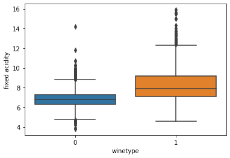

```python
import matplotlib.pyplot as plt

sns.boxplot(x='winetype', y='fixed acidity', data=wine)
```

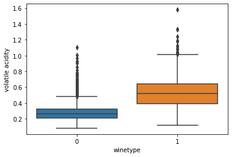

```python
sns.boxplot(x='winetype', y='volatile acidity', data=wine)
```

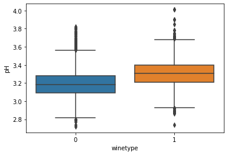

```python
sns.boxplot(x='winetype', y='pH', data=wine)
```

### Qn2.2) Split data into training and test set. Build models that evaluate the relationship between all available X variables in the dataset and the target variable. Evaluate Logistic Regression, Penalized Logistic Regression, and KNN for classification using cross-validation. How different are the results? How does scaling the data with StandardScaler influence the results?

#### Split data into training and test set.

```python
Y = wine['winetype']
X = wine.loc[:, wine.columns != 'winetype']
X_train, X_test, y_train, y_test = train_test_split(X, Y, random_state=42)
X.head()
```

|  | fixed acidity | volatile acidity | citric acid | residual sugar | chlorides | free sulfur dioxide | total sulfur dioxide | density | pH | sulphates | alcohol | quality |
| --- | --- | --- | --- | --- | --- | --- | --- | --- | --- | --- | --- | --- |
| 0 | 7.0 | 0.27 | 0.36 | 20.7 | 0.045 | 45.0 | 170.0 | 1.0010 | 3.00 | 0.45 | 8.8 | 6 |
| 1 | 6.3 | 0.30 | 0.34 | 1.6 | 0.049 | 14.0 | 132.0 | 0.9940 | 3.30 | 0.49 | 9.5 | 6 |
| 2 | 8.1 | 0.28 | 0.40 | 6.9 | 0.050 | 30.0 | 97.0 | 0.9951 | 3.26 | 0.44 | 10.1 | 6 |
| 3 | 7.2 | 0.23 | 0.32 | 8.5 | 0.058 | 47.0 | 186.0 | 0.9956 | 3.19 | 0.40 | 9.9 | 6 |
| 4 | 7.2 | 0.23 | 0.32 | 8.5 | 0.058 | 47.0 | 186.0 | 0.9956 | 3.19 | 0.40 | 9.9 | 6 |

#### Logistic Regression using cross-validation (Unscaled)

```python
from sklearn.linear_model import LogisticRegression

log_reg = LogisticRegression(max_iter = 10000).fit(X_train, y_train)

print("Training Set Score: {:.4f}".format(log_reg.score(X_train, y_train)))
print("Test Set Score: {:.4f}".format(log_reg.score(X_test, y_test)))
print("Unscaled KFold Cross Validation: {:.4f}".format(np.mean(cross_val_score(log_reg, X_train, y_train, cv=kfold))))
```

```
Training Set Score: 0.9865
Test Set Score: 0.9809
Unscaled KFold Cross Validation: 0.9858
```

#### Penalized Logistic Regression using cross-validation (Unscaled)

```python
pen_logreg = LogisticRegression(penalty = 'l2',solver = 'liblinear').fit(X_train, y_train)

print("Training Set Score: {:.4f}".format(pen_logreg.score(X_train, y_train)))
print("Test Set Score: {:.4f}".format(pen_logreg.score(X_test, y_test)))
print("Unscaled KFold Cross Validation: {:.4f}".format(np.mean(cross_val_score(pen_logreg, X_train, y_train, cv=kfold))))
```

```
Training Set Score: 0.9828
Test Set Score: 0.9766
Unscaled KFold Cross Validation: 0.9817
```

#### KNN for classification using cross-validation (Unscaled)

```python
from sklearn.neighbors import KNeighborsClassifier

knn = KNeighborsClassifier().fit(X_train, y_train)

print("Training Set Score: {:.4f}".format(knn.score(X_train, y_train)))
print("Test Set Score: {:.4f}".format(knn.score(X_test, y_test)))
print("Unscaled KFold Cross Validation: {:.4f}".format(np.mean(cross_val_score(knn, X_train, y_train, cv=kfold))))
```

```
Training Set Score: 0.9575
Test Set Score: 0.9360
Unscaled KFold Cross Validation: 0.9395
```

#### How different are the results?

Logistic Regression has the highest average accuracy (0.9858) followed by Penalized Logistic Regression (0.9817). KNN for classification has the lowest average accuracy (0.9395).

#### How does scaling the data with StandardScaler influence the results?

#### Logistic Regression using cross-validation (Scaled)

```python
scaler = StandardScaler().fit(X_train)
scaled_X_train = scaler.transform(X_train)
scaled_X_test = scaler.transform(X_test)

scaled_logreg = LogisticRegression().fit(scaled_X_train, y_train)

print("Training Set Score: {:.4f}".format(scaled_logreg.score(scaled_X_train, y_train)))
print("Test Set Score: {:.4f}".format(scaled_logreg.score(scaled_X_test, y_test)))
print("Scaled KFold Cross Validation: {:.4f}".format(np.mean(cross_val_score(scaled_logreg, scaled_X_train, y_train, cv=kfold))))
```

```
Training Set Score: 0.9936
Test Set Score: 0.9914
Scaled KFold Cross Validation: 0.9928
```

We can see from the result that scaling the data with the StandardScaler has improved the average accuracy of the logistic regression model.

#### Penalized Logistic Regression using cross-validation (Scaled)

```python
scaled_pen_logreg = LogisticRegression(penalty = 'l2',solver = 'liblinear').fit(scaled_X_train, y_train)

print("Training Set Score: {:.4f}".format(scaled_pen_logreg.score(scaled_X_train, y_train)))
print("Test Set Score: {:.4f}".format(scaled_pen_logreg.score(scaled_X_test, y_test)))
print("Scaled KFold Cross Validation: {:.4f}".format(np.mean(cross_val_score(scaled_pen_logreg, scaled_X_train, y_train, cv=kfold))))
```

```
Training Set Score: 0.9940
Test Set Score: 0.9920
Scaled KFold Cross Validation: 0.9932
```

We can see from the result that scaling the data with the StandardScaler has improved the average accuracy of the penalised logistic regression model.

#### KNN for classification using cross-validation (Scaled)

```python
scaled_knn = KNeighborsClassifier().fit(scaled_X_train, y_train)

print("Training Set Score: {:.4f}".format(scaled_knn.score(scaled_X_train, y_train)))
print("Test Set Score: {:.4f}".format(scaled_knn.score(scaled_X_test, y_test)))
print("Scaled KFold Cross Validation: {:.4f}".format(np.mean(cross_val_score(scaled_knn, scaled_X_train, y_train, cv=kfold))))
```

```
Training Set Score: 0.9953
Test Set Score: 0.9914
Scaled KFold Cross Validation: 0.9930
```

We can see from the result that scaling the data with the StandardScaler has improved the average accuracy of the knn for classification.

### Qn2.3) Tune the parameters where possible using GridSearchCV. Do the results improve?

#### Logistic Regression with GridSearchCV

```python
logreg_pipe = make_pipeline(StandardScaler(), LogisticRegression())
logreg_param_grid = {'logisticregression__C': np.logspace(-5, 5, 10)}

logreg_grid = GridSearchCV(logreg_pipe, logreg_param_grid,cv = kfold).fit(scaled_X_train, y_train)


print("Best Parameter: {}".format(logreg_grid.best_params_))
print("After Test Set Score: {:.4f}".format(logreg_grid.score(scaled_X_test, y_test)))
print("Before Test Set Score: {:.4f}".format(np.mean(cross_val_score(scaled_logreg, scaled_X_train, y_train, cv=kfold))))
```

```
Best Parameter: {'logisticregression__C': 46.41588833612782}
After Test Set Score: 0.9932
Before Test Set Score: 0.9928
```

The result improves after using GridSearchCV.

#### Penalized Logistic Regression with GridSearchCV

```python
pen_logreg_pipe = make_pipeline(StandardScaler(), LogisticRegression(penalty = 'l2',solver = 'liblinear'))

pen_logreg_param_grid = {'logisticregression__C': np.logspace(-5, 5, 10)}
pen_logreg_grid = GridSearchCV(pen_logreg_pipe, pen_logreg_param_grid, cv = kfold).fit(scaled_X_train, y_train)

print("Best Parameter: {}".format(pen_logreg_grid.best_params_))
print("After Test Set Score: {:.4f}".format(pen_logreg_grid.score(scaled_X_test, y_test)))
print("Before Test Set Score: {:.4f}".format(np.mean(cross_val_score(scaled_pen_logreg, scaled_X_train, y_train, cv=kfold))))
```

```
Best Parameter: {'logisticregression__C': 0.2782559402207126}
After Test Set Score: 0.9914
Before Test Set Score: 0.9932
```

The result did not improve after using GridSearchCV.

#### KNN for classification with GridSearchCV

```python
knn_pipe = make_pipeline(StandardScaler(), KNeighborsClassifier())

knn_param_grid = {'kneighborsclassifier__n_neighbors': np.arange(1, 18, 3)}
knn_grid = GridSearchCV(knn_pipe, knn_param_grid, cv= kfold).fit(scaled_X_train, y_train)

print("Best Parameter: {}".format(knn_grid.best_params_))
print("After Test Set Score: {:.4f}".format(knn_grid.score(scaled_X_test, y_test)))
print("Before Test Set Score: {:.4f}".format(np.mean(cross_val_score(scaled_knn, scaled_X_train, y_train, cv=kfold))))
```

```
Best Parameter: {'kneighborsclassifier__n_neighbors': 1}
After Test Set Score: 0.9914
Before Test Set Score: 0.9930
```

The result did not improve after using GridSearchCV.

### Qn2.4) Change the cross-validation strategy in GridSearchCV from ‘stratified k-fold’ to ‘kfold’ with shuffling. Do the parameters for models that can be tuned change? Do they change if you change the random seed of the shuffling? Or if you change the random state of the split into training and test data?

#### Logistic Regression

```python
logreg_pipe = make_pipeline(StandardScaler(), LogisticRegression())
logreg_param_grid = {'logisticregression__C': np.logspace(-5, 5, 10)}

logreg_grid_skfold = GridSearchCV(logreg_pipe, logreg_param_grid, cv = skfold).fit(scaled_X_train, y_train)
logreg_grid_rkf = GridSearchCV(logreg_pipe, logreg_param_grid, cv = rkf).fit(scaled_X_train, y_train)


print("Best Parameter skfold: {}".format(logreg_grid_skfold.best_params_))
print("Best Parameter rkf: {}".format(logreg_grid_rkf.best_params_))
```

```
Best Parameter skfold: {'logisticregression__C': 46.41588833612782}
Best Parameter rkf: {'logisticregression__C': 3.593813663804626}
```

The best parameter changes from 46.416 to 3.594.

#### Penalized Logistic Regression

```python
pen_logreg_pipe = make_pipeline(StandardScaler(), LogisticRegression(penalty = 'l2',solver = 'liblinear'))
pen_logreg_param_grid = {'logisticregression__C': np.logspace(-5, 5, 10)}

pen_logreg_grid_skfold = GridSearchCV(pen_logreg_pipe, pen_logreg_param_grid, cv = skfold).fit(scaled_X_train, y_train)
pen_logreg_grid_rkf = GridSearchCV(pen_logreg_pipe, pen_logreg_param_grid, cv = rkf).fit(scaled_X_train, y_train)

print("Best Parameter skfold: {}".format(pen_logreg_grid_skfold.best_params_))
print("Best Parameter rkf: {}".format(pen_logreg_grid_rkf.best_params_))
```

```
Best Parameter skfold: {'logisticregression__C': 3.593813663804626}
Best Parameter rkf: {'logisticregression__C': 3.593813663804626}
```

The best parameter does not change.

#### knn for classification

```python
knn_pipe = make_pipeline(StandardScaler(), KNeighborsClassifier())
knn_param_grid = {'kneighborsclassifier__n_neighbors': np.arange(1, 18, 3)}

knn_grid_skfold = GridSearchCV(knn_pipe, knn_param_grid, cv = skfold).fit(scaled_X_train, y_train)
knn_grid_rkf = GridSearchCV(knn_pipe, knn_param_grid, cv = rkf).fit(scaled_X_train, y_train)

print("Best Parameter skfold: {}".format(knn_grid_skfold.best_params_))
print("Best Parameter rkf: {}".format(knn_grid_rkf.best_params_))
```

```
Best Parameter skfold: {'kneighborsclassifier__n_neighbors': 13}
Best Parameter rkf: {'kneighborsclassifier__n_neighbors': 16}
```

The best parameter changes from 13 to 16.

### Change the random seed of the shuffling from 42 to 20

```python
rkf2 = RepeatedKFold(n_splits=10, n_repeats=4, random_state = 20)
```

#### Logistic Regression

```python
logreg_pipe = make_pipeline(StandardScaler(), LogisticRegression())
logreg_param_grid = {'logisticregression__C': np.logspace(-5, 5, 10)}

logreg_grid_rkf2 = GridSearchCV(logreg_pipe, logreg_param_grid, cv = rkf2).fit(scaled_X_train, y_train)


print("Best Parameter rkf: {}".format(logreg_grid_rkf.best_params_))
print("Best Parameter rkf2: {}".format(logreg_grid_rkf2.best_params_))
```

```
Best Parameter rkf: {'logisticregression__C': 3.593813663804626}
Best Parameter rkf2: {'logisticregression__C': 46.41588833612782}
```

The best parameter changes from 3.59 to 46.42.

#### Penalized Logistic Regression

```python
pen_logreg_pipe = make_pipeline(StandardScaler(), LogisticRegression(penalty = 'l2',solver = 'liblinear'))
pen_logreg_param_grid = {'logisticregression__C': np.logspace(-5, 5, 10)}

pen_logreg_grid_rkf = GridSearchCV(pen_logreg_pipe, pen_logreg_param_grid, cv = rkf).fit(scaled_X_train, y_train)
pen_logreg_grid_rkf2 = GridSearchCV(pen_logreg_pipe, pen_logreg_param_grid, cv = rkf2).fit(scaled_X_train, y_train)

print("Best Parameter rkf: {}".format(pen_logreg_grid_rkf.best_params_))
print("Best Parameter rkf2: {}".format(pen_logreg_grid_rkf2.best_params_))
```

```
Best Parameter rkf: {'logisticregression__C': 3.593813663804626}
Best Parameter rkf2: {'logisticregression__C': 0.2782559402207126}
```

The best parameter changes from 3.59 to 0.28.

#### knn for classification

```python
knn_pipe = make_pipeline(StandardScaler(), KNeighborsClassifier())
knn_param_grid = {'kneighborsclassifier__n_neighbors': np.arange(1, 18, 3)}

knn_grid_rkf = GridSearchCV(knn_pipe, knn_param_grid, cv = rkf).fit(scaled_X_train, y_train)
knn_grid_rkf2 = GridSearchCV(knn_pipe, knn_param_grid, cv = rkf2).fit(scaled_X_train, y_train)

print("Best Parameter rkf: {}".format(knn_grid_rkf.best_params_))
print("Best Parameter rkf2: {}".format(knn_grid_rkf2.best_params_))
```

```
Best Parameter rkf: {'kneighborsclassifier__n_neighbors': 16}
Best Parameter rkf2: {'kneighborsclassifier__n_neighbors': 4}
```

The best parameter changes from 16 to 4.

### Change the random state of the split into training and test data

```python
X_train2, X_test2, y_train2, y_test2 = train_test_split(X, Y, random_state=20)

scaler = StandardScaler().fit(X_train2)
scaled2_X_train = scaler.transform(X_train2)
scaled2_X_test = scaler.transform(X_test2)
```

#### Logistic Regression

```python
logreg_grid_rkf2 = GridSearchCV(logreg_pipe, logreg_param_grid, cv = rkf2).fit(scaled_X_train, y_train)
logreg_grid_rkfnew = GridSearchCV(logreg_pipe, logreg_param_grid, cv = rkf2).fit(scaled2_X_train, y_train2)

print("Best Parameter rkf2: {}".format(logreg_grid_rkf2.best_params_))
print("Best Parameter rkfnew: {}".format(logreg_grid_rkfnew.best_params_))
```

```
Best Parameter rkf2: {'logisticregression__C': 46.41588833612782}
Best Parameter rkfnew: {'logisticregression__C': 599.4842503189421}
```

The best parameter changes from 46.42 to 599.48.

#### Penalized Logistic Regression

```python
pen_logreg_grid_rkf2 = GridSearchCV(pen_logreg_pipe, pen_logreg_param_grid, cv = rkf2).fit(scaled_X_train, y_train)
pen_logreg_grid_rkfnew = GridSearchCV(pen_logreg_pipe, pen_logreg_param_grid, cv = rkf2).fit(scaled2_X_train, y_train2)

print("Best Parameter rkf2: {}".format(pen_logreg_grid_rkf2.best_params_))
print("Best Parameter rkfnew: {}".format(pen_logreg_grid_rkfnew.best_params_))
```

```
Best Parameter rkf2: {'logisticregression__C': 0.2782559402207126}
Best Parameter rkfnew: {'logisticregression__C': 599.4842503189421}
```

The best parameter changes from 0.278 to 599.484.

#### knn for classification

```python
knn_grid_rkf2 = GridSearchCV(knn_pipe, knn_param_grid, cv = rkf2).fit(scaled_X_train, y_train)
knn_grid_rkfnew = GridSearchCV(knn_pipe, knn_param_grid, cv = rkf2).fit(scaled2_X_train, y_train2)

print("Best Parameter rkf2: {}".format(knn_grid_rkf2.best_params_))
print("Best Parameter rkfnew: {}".format(knn_grid_rkfnew.best_params_))
```

```
Best Parameter rkf2: {'kneighborsclassifier__n_neighbors': 4}
Best Parameter rkfnew: {'kneighborsclassifier__n_neighbors': 16}
```

The best parameter changes from 4 to 16.

### Qn2.5) Lastly, compare the coefficients for Logistic Regression and Penalized Logistic Regression and discuss which final model you would choose to predict new data.

```python
coef_logreg = pd.DataFrame(data = scaled_logreg .coef_, columns = X_train.columns, index = ['Logistic Regression'])
coef_pen_logreg = pd.DataFrame(data = scaled_pen_logreg.coef_, columns = X_train.columns, index = ['Penalized Logistic Regression'])
```

```python
coef_logreg.append(coef_pen_logreg)
```

|  | fixed acidity | volatile acidity | citric acid | residual sugar | chlorides | free sulfur dioxide | total sulfur dioxide | density | pH | sulphates | alcohol | quality |
| --- | --- | --- | --- | --- | --- | --- | --- | --- | --- | --- | --- | --- |
| Logistic Regression | 0.355438 | 1.280869 | -0.359597 | -3.521214 | 0.793006 | 0.928958 | -2.918439 | 3.497433 | 0.320909 | 0.635613 | 1.204437 | 0.162930 |
| Penalized Logistic Regression | 0.280487 | 1.224668 | -0.362057 | -3.290750 | 0.751321 | 0.927189 | -2.852859 | 3.554924 | 0.255621 | 0.588355 | 1.221681 | 0.182026 |

I would choose penalized logistic regression to predict new data as its shrink effect can help us highlight important variables. Also, from the prespective of average accuracy after standardizing, penalized logistic regressionhas a slightly higher accuracy of 0.9932 compared to logistic regression of 0.9928.